# Machine Learning

> Machine Learning is the field of study that gives computers the ability to learn without being explicitly programmed.

Arthur Samuel, 1959

## Clasificando especies de Iris

- largo del pétalo y ancho del pétalo
- largo del sépalo y ancho del sépalo

Las clases a distinguir son:

- setosa
- versicolor
- virginica

Cargando el dataset de *Iris*

```python
from sklearn.datasets import load_iris
iris_dataset = load_iris()
```

El dataset viene como un diccionario. Las claves del diccionario de iris son:

```python
iris_dataset.keys()
```

```
dict_keys(['data', 'target', 'target_names', 'DESCR', 'feature_names', 'filename'])
```

Se va a resolver este problema con el enfoque supervisado de Machine Learning, ya que disponemos las medidas (longitud, ancho) del pétalo y el sépalo de cada tipo de flor.

Las medidas registradas son el vector de características $\mathbf{X}$

Las clases identificadas por el experto (setosa, versicolor, virginica) son $\mathcal{Y}$

Resumiendo:

Se desea encontrar una función $g: \mathcal{X} \rightarrow \mathcal{Y}$ que aproxime a la función verdadera $f: \mathcal{X} \rightarrow \mathcal{Y}$. Donde:

$\mathbf{X} = \{longitud\_sepalo, ancho\_sepalo, longitud\_petalo, ancho\_petalo\}$

$\mathcal{Y} = \{setosa, versicolor, virginica\}$

Por tanto se tiene un conjunto de datos $\mathcal{D}$ tal que se forma de parejas $(\mathbf{x}_{1},y_{1}), (\mathbf{x}_{2},y_{2}) \dots (\mathbf{x}_{N},y_{N}) $

```python
print("Vector de características \n{}".format(iris_dataset.feature_names))
```

```
Vector de características
['sepal length (cm)', 'sepal width (cm)', 'petal length (cm)', 'petal width (cm)']
```

```python
iris_dataset.data[0:5]
```

```
array([[5.1, 3.5, 1.4, 0.2],
       [4.9, 3. , 1.4, 0.2],
       [4.7, 3.2, 1.3, 0.2],
       [4.6, 3.1, 1.5, 0.2],
       [5. , 3.6, 1.4, 0.2]])
```

$\mathcal{Y} = \{setosa, versicolor, virginica\} = \{0,1,2\}$

```python
print("Etiquetas \n{}".format(iris_dataset.target_names))
```

```
Etiquetas
['setosa' 'versicolor' 'virginica']
```

```python
iris_dataset.target[10:145]
```

```
array([0, 0, 0, 0, 0, 0, 0, 0, 0, 0, 0, 0, 0, 0, 0, 0, 0, 0, 0, 0, 0, 0,
       0, 0, 0, 0, 0, 0, 0, 0, 0, 0, 0, 0, 0, 0, 0, 0, 0, 0, 1, 1, 1, 1,
       1, 1, 1, 1, 1, 1, 1, 1, 1, 1, 1, 1, 1, 1, 1, 1, 1, 1, 1, 1, 1, 1,
       1, 1, 1, 1, 1, 1, 1, 1, 1, 1, 1, 1, 1, 1, 1, 1, 1, 1, 1, 1, 1, 1,
       1, 1, 2, 2, 2, 2, 2, 2, 2, 2, 2, 2, 2, 2, 2, 2, 2, 2, 2, 2, 2, 2,
       2, 2, 2, 2, 2, 2, 2, 2, 2, 2, 2, 2, 2, 2, 2, 2, 2, 2, 2, 2, 2, 2,
       2, 2, 2])
```

El ejemplo : $(\mathbf{x}_{121},y_{121})$ es

```python
x_121 = iris_dataset.data[121]
y_121 = iris_dataset.target[121]
print('vector caracteristicas: {}, etiqueta: {}'.format(x_121, y_121))
```

```
vector caracteristicas: [5.6 2.8 4.9 2. ], etiqueta: 2
```

El tensor que contiene los datos tiene una forma de $150 \times 4$. Lo que significa que tenemos un total de 150 ejemplos, con 4 caracteristicas y 150 etiquetas. Cada ejemplo se llama muestra (*sample*)

```python
iris_dataset['data'].shape
```

```
(150, 4)
```

## Evaluación de Desempeño del algoritmo de aprendizaje

- Training Set
- Validation Set
- Test Set

En la mayoría de casos se suele utilizar únicamente los 2 primeros. El **Validation set** se utiliza para realizar mejoras a los hiperparámetros del modelo de tal manera que se mejore **la funcion de costo** y la **precision(accuracy)** del modelo. El Test Set en cambio es un conjunto de datos a los que el modelo nunca esta expuesto y que sirve para medir la capacidad de generalización del mismo frente a **nuevos datos**

Método train test split: https://scikit-learn.org/stable/modules/generated/sklearn.model_selection.train_test_split.html

```python
from sklearn.model_selection import train_test_split
x_train, x_test, y_train, y_test = train_test_split(iris_dataset['data'],
                                                    iris_dataset['target'],
                                                    test_size=0.3, random_state=41)
```

Total de muestras de entrenamiento $\mathbf{X}$ y $\mathcal{Y}$

```python
print("la forma de la matriz X de entrenamiento es: {}".format(x_train.shape))
```

```
la forma de la matriz X de entrenamiento es: (105, 4)
```

```python
x_test.shape
```

```
(45, 4)
```

```python
print("la forma de la matriz Y de entrenamiento es: {}".format(y_train.shape))
```

```
la forma de la matriz Y de entrenamiento es: (105,)
```

### Ejercicio:

Imprima la forma de las matrices de test

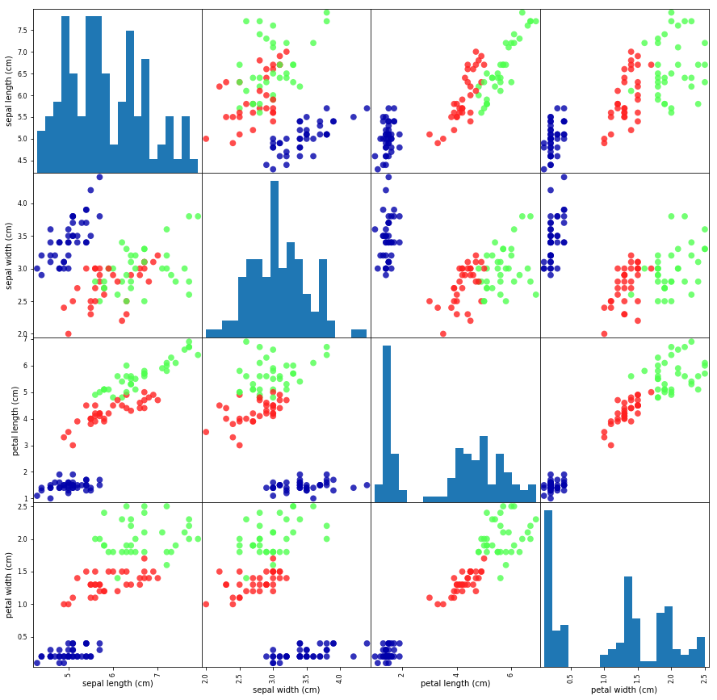

```python
import pandas as pd
import mglearn
# create dataframe from data in X_train
# label the columns using the strings in iris_dataset.feature_names
iris_dataframe = pd.DataFrame(x_train, columns=iris_dataset.feature_names)
# create a scatter matrix from the dataframe, color by y_train
grr = pd.scatter_matrix(iris_dataframe,
                        c=y_train,
                        figsize=(15, 15),
                        marker='o',
                        hist_kwds={'bins': 20},
                        s=60, alpha=.8, cmap=mglearn.cm3)
# pd.plotting(grr)
```

## K-Nearest Neighbors

- Asume que toda instancia corresponde a puntos en un spacio $n$ - dimensional $R^{n}$
- Los vecinos más cercanos se definen en términos de una medida de distancia e.g. La distancia Euclidea.

Por ejemplo, si una muestra de $\mathcal{X}$ del dataset $\mathcal{D}$ es un vector de características:

$\mathbf{x}_{r} = <x_{r,1},x_{r,2},\dots, x_{r,n}>$, entonces, la distancia entre dos datos $i$ y $j$ es:

$d(\mathbf{x}_{i}, \mathbf{x}_{j})=\sqrt{\sum_{k=1}^{n}({x}_{i,k}-{x}_{j,k})^{2}}$

- La función objetivo (**target function**) en KNN puede ser discreta(clasificación) o real(regresión)

## Algoritmo KNN

Training:

- Para cada ejemplo de entrenamiento $(\mathbf{x}, y)$, añada el ejemplo a la lista de entrenamiento.

Clasification: Dada una instancia $x_{q}$ a ser clasificada

- Defina un valor de $k$ vecinos próximos. Teniendo $\mathbf{x}_{1}, \mathbf{x}_{2} \dots, \mathbf{x}_{n} $ muestras del conjunto de **ejemplos de entrenamiento** y calcule su distancia a $q$
- Devuelva el voto de la mayoría

$g(\mathbf{x}_{q}) = argmax \sum_{i=1}^{k}\delta(y_{verdadero}, f(\mathbf{x}_{i}))$

Donde: $\delta(y_{verdadero}, f(\mathbf{x}_{i})) = 1$ si $y_{verdadero}=f(\mathbf{x}_{i})$ y $\delta(y_{verdadero}, f(\mathbf{x}_{i})) = 0$, caso contrario

```python
from sklearn.neighbors import KNeighborsClassifier
knn = KNeighborsClassifier(n_neighbors=2, algorithm='brute')
knn.fit(x_train, y_train)
```

```
KNeighborsClassifier(algorithm='brute', leaf_size=30, metric='minkowski',
           metric_params=None, n_jobs=None, n_neighbors=2, p=2,
           weights='uniform')
```

Para que jupyter o ipython imprima información sobre le objeto/método usado:

```python
KNeighborsClassifier?
```

### Evaluando KNN

```python
knn.score(x_test, y_test)
```

```
0.8888888888888888
```

```python
y_pred = knn.predict(x_test)
```

```python
import pandas as pd
dicc = {'y_predict':y_pred, 'y_verdadero':y_test}
dataf = pd.DataFrame.from_dict(dicc)
dataf
# print(y_test)
# print(y_pred)
```

|  | y_predict | y_verdadero |
| --- | --- | --- |
| 0 | 1 | 2 |
| 1 | 2 | 2 |
| 2 | 2 | 2 |
| 3 | 1 | 1 |
| 4 | 2 | 2 |
| 5 | 1 | 1 |
| 6 | 2 | 2 |
| 7 | 1 | 1 |
| 8 | 2 | 2 |
| 9 | 2 | 2 |
| 10 | 2 | 2 |
| 11 | 0 | 0 |
| 12 | 0 | 0 |
| 13 | 1 | 1 |
| 14 | 0 | 0 |
| 15 | 1 | 2 |
| 16 | 0 | 0 |
| 17 | 2 | 1 |
| 18 | 0 | 0 |
| 19 | 0 | 0 |
| 20 | 1 | 1 |
| 21 | 2 | 2 |
| 22 | 0 | 0 |
| 23 | 0 | 0 |
| 24 | 1 | 1 |
| 25 | 1 | 1 |
| 26 | 1 | 1 |
| 27 | 1 | 1 |
| 28 | 0 | 0 |
| 29 | 1 | 1 |
| 30 | 1 | 1 |
| 31 | 1 | 1 |
| 32 | 1 | 2 |
| 33 | 1 | 1 |
| 34 | 2 | 2 |
| 35 | 0 | 0 |
| 36 | 2 | 2 |
| 37 | 1 | 1 |
| 38 | 2 | 2 |
| 39 | 2 | 1 |
| 40 | 1 | 1 |
| 41 | 1 | 1 |
| 42 | 0 | 0 |
| 43 | 2 | 2 |
| 44 | 2 | 2 |

## Prediciendo nuevos datos

```python
import numpy as np
x_new = np.array([[5, 2.9, 1, 0.2]])
y_new = knn.predict(x_new)
y_new_label = iris_dataset['target_names'][y_new]
print('Valor que predice knn para x: {}: {}'.format(x_new, y_new))
print('Etiqueta:{}'.format(y_new_label))
```

```
Valor que predice knn para x: [[5.  2.9 1.  0.2]]: [0]
Etiqueta:['setosa']
```

```python
lista_clase = {'katherine':[20, 'piscis', 'soul'],
               'henry' :[23, 'no-se', 'reggeton'],
               'jose':[20, 'piscis', 'soul'],
               'marilyn':[20, 'piscis', 'soul'],
               'freddy':[20, 'piscis', 'soul'],
               'diana':[20, 'piscis', 'soul'],
               'el_profe':[999, 'geminis', 'metal-sinfonico']
              }
```

```python
data_frame_lista = pd.DataFrame.from_dict(lista_clase)
data_frame_lista
```

|  | katherine | henry | jose | marilyn | freddy | diana | el_profe |
| --- | --- | --- | --- | --- | --- | --- | --- |
| 0 | 20 | 23 | 20 | 20 | 20 | 20 | 999 |
| 1 | piscis | no-se | piscis | piscis | piscis | piscis | geminis |
| 2 | soul | reggeton | soul | soul | soul | soul | metal-sinfonico |

## Ejercicios:

1. Muestre usando pandas dataframe los resultados de y_ground_truth y y_predict
2. Realice un programa en el que pueda cambiar los valores de $k$ y grafique el score obtenido en cada caso
3. K-nearest tambien se puede utilizar para realizar prediciones sobre regresión de números reales. Encuentre un dataset y presente los resultados